# R Notebook

```r
diamonds <- read.delim("HW-diamonds.txt", header = FALSE, sep = "", dec = ".")
```

```r
head(diamonds)
```

|  | V1 | V2 | V3 | V4 | V5 |
| --- | --- | --- | --- | --- | --- |
| 1 | 0.30 | D | VS2 | GIA | 1302 |
| 2 | 0.30 | E | VS1 | GIA | 1510 |
| 3 | 0.30 | G | VVS1 | GIA | 1510 |
| 4 | 0.30 | G | VS1 | GIA | 1260 |
| 5 | 0.31 | D | VS1 | GIA | 1641 |
| 6 | 0.31 | E | VS1 | GIA | 1555 |

```r
colnames(diamonds) <- c("caratage", "purity", "clarity", "certificate", "price")
diamonds$purity <- factor(diamonds$purity, levels=c("D", "E", "F", "G", "H", "I"))
diamonds$clarity <- factor(diamonds$clarity, levels=c("VS2", "VS1", "VVS2", "VVS1", "IF"))
```

```r
summary(diamonds)
```

```
    caratage      purity clarity   certificate     price
 Min.   :0.1800   D:16   VS2 :53   GIA:151     Min.   :  638
 1st Qu.:0.3500   E:44   VS1 :81   HRD: 79     1st Qu.: 1625
 Median :0.6200   F:82   VVS2:78   IGI: 78     Median : 4215
 Mean   :0.6309   G:65   VVS1:52               Mean   : 5019
 3rd Qu.:0.8500   H:61   IF  :44               3rd Qu.: 7446
 Max.   :1.1000   I:40                         Max.   :16008
```

```r
library(dplyr)
library(ggplot2)
library(tseries)
library(lmtest)
library(car)
```

### 1. Plot price vs caratage and log(price) vs caratage. Decide on which response variable is better to use

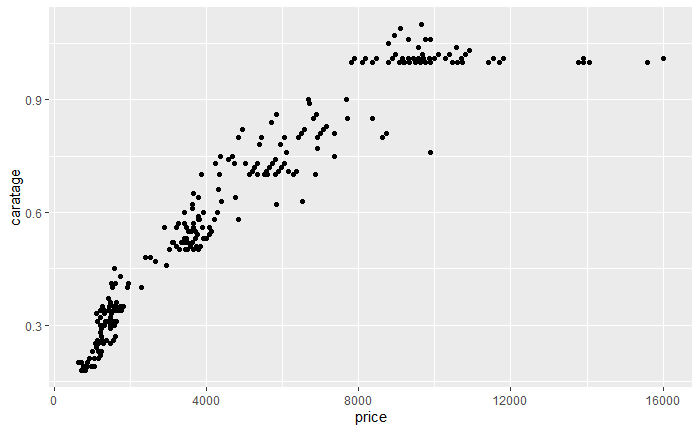

```r
ggplot(data=diamonds, aes(price, caratage)) +
        geom_point()
```

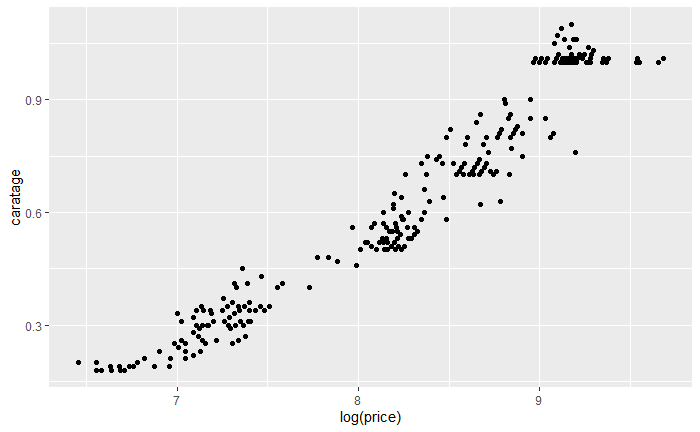

```r
ggplot(data=diamonds, aes(log(price), caratage)) +
        geom_point()
```

log(price) seems more linear (maybe different transformations?)

### 2. Find a suitable way to include, besides caratage, the other categorical information

available: clarity, color and certificate. Use the worst level of each categorical variable as the reference category and HRD for certification institution. Comment on the model fitted, and perform a basic analysis of the residuals (normality, constant variance, independence, you may also want to use the function outlierTest or residualPlot ).

```r
#Starting model
model.1.1<-lm(formula = price ~ caratage + purity + clarity + certificate, data = diamonds)
summary(model.1.1)
```

```
Call:
lm(formula = price ~ caratage + purity + clarity + certificate,
    data = diamonds)

Residuals:
    Min      1Q  Median      3Q     Max
-1740.0  -428.8  -128.3   314.3  3634.1

Coefficients:
               Estimate Std. Error t value Pr(>|t|)
(Intercept)    -1622.83     247.65  -6.553 2.51e-10 ***
caratage       12766.40     190.02  67.183  < 2e-16 ***
purityE        -1439.09     207.98  -6.919 2.83e-11 ***
purityF        -1841.69     195.23  -9.433  < 2e-16 ***
purityG        -2176.67     200.39 -10.862  < 2e-16 ***
purityH        -2747.15     202.91 -13.538  < 2e-16 ***
purityI        -3313.10     212.71 -15.575  < 2e-16 ***
clarityVS1       317.44     128.09   2.478   0.0138 *
clarityVVS2      600.85     130.28   4.612 5.95e-06 ***
clarityVVS1     1102.72     144.45   7.634 3.18e-13 ***
clarityIF       1792.01     171.19  10.468  < 2e-16 ***
certificateHRD    15.23     107.25   0.142   0.8872
certificateIGI   141.26     128.26   1.101   0.2716
---
Signif. codes:  0 ‘***’ 0.001 ‘**’ 0.01 ‘*’ 0.05 ‘.’ 0.1 ‘ ’ 1

Residual standard error: 710.4 on 295 degrees of freedom
Multiple R-squared:  0.9581,    Adjusted R-squared:  0.9564
F-statistic: 562.5 on 12 and 295 DF,  p-value: < 2.2e-16
```

```r
#Let's try to predict log(price)
model.1.2<-lm(formula = log(price) ~ caratage + purity + clarity + certificate, data = diamonds)
summary(model.1.2)
```

```
Call:
lm(formula = log(price) ~ caratage + purity + clarity + certificate,
    data = diamonds)

Residuals:
     Min       1Q   Median       3Q      Max
-0.31236 -0.11520  0.01613  0.10833  0.36339

Coefficients:
                Estimate Std. Error t value Pr(>|t|)
(Intercept)     6.502651   0.048178 134.971  < 2e-16 ***
caratage        2.855013   0.036968  77.230  < 2e-16 ***
purityE        -0.029509   0.040461  -0.729  0.46638
purityF        -0.106358   0.037981  -2.800  0.00544 **
purityG        -0.206349   0.038985  -5.293 2.35e-07 ***
purityH        -0.287876   0.039475  -7.293 2.81e-12 ***
purityI        -0.416557   0.041382 -10.066  < 2e-16 ***
clarityVS1      0.096609   0.024919   3.877  0.00013 ***
clarityVVS2     0.201923   0.025344   7.967 3.56e-14 ***
clarityVVS1     0.297835   0.028102  10.598  < 2e-16 ***
clarityIF       0.298541   0.033303   8.964  < 2e-16 ***
certificateHRD -0.008856   0.020864  -0.424  0.67155
certificateIGI -0.182711   0.024952  -7.323 2.33e-12 ***
---
Signif. codes:  0 ‘***’ 0.001 ‘**’ 0.01 ‘*’ 0.05 ‘.’ 0.1 ‘ ’ 1

Residual standard error: 0.1382 on 295 degrees of freedom
Multiple R-squared:  0.9723,    Adjusted R-squared:  0.9712
F-statistic: 863.6 on 12 and 295 DF,  p-value: < 2.2e-16
```

```r
#model1.2 has a lower residual standard error and a higher R^2. We will predict log(price).
```

```r
#By default, the category that R chooses to be the reference or baseline, is the first category that appears alphabetically or  numerically (if categories are coded using 0,1,2,...).
#Let's use the worst level of each categorical variable as the reference category and HRD for certification institution.
diamonds$purity <- relevel(diamonds$purity, ref = "I")
diamonds$clarity <- relevel(diamonds$clarity, ref = "VS2")
diamonds$certificate <- relevel(diamonds$certificate, ref = "HRD")
model.1.3<-lm(formula = log(price) ~ caratage + purity + clarity + certificate, data = diamonds)
summary(model.1.3)
```

```
Call:
lm(formula = log(price) ~ caratage + purity + clarity + certificate,
    data = diamonds)

Residuals:
     Min       1Q   Median       3Q      Max
-0.31236 -0.11520  0.01613  0.10833  0.36339

Coefficients:
                Estimate Std. Error t value Pr(>|t|)
(Intercept)     6.077239   0.048091 126.369  < 2e-16 ***
caratage        2.855013   0.036968  77.230  < 2e-16 ***
purityD         0.416557   0.041382  10.066  < 2e-16 ***
purityE         0.387047   0.030824  12.557  < 2e-16 ***
purityF         0.310198   0.027479  11.288  < 2e-16 ***
purityG         0.210207   0.028359   7.412 1.32e-12 ***
purityH         0.128681   0.028523   4.511 9.31e-06 ***
clarityVS1      0.096609   0.024919   3.877  0.00013 ***
clarityVVS2     0.201923   0.025344   7.967 3.56e-14 ***
clarityVVS1     0.297835   0.028102  10.598  < 2e-16 ***
clarityIF       0.298541   0.033303   8.964  < 2e-16 ***
certificateGIA  0.008856   0.020864   0.424  0.67155
certificateIGI -0.173855   0.028673  -6.063 4.07e-09 ***
---
Signif. codes:  0 ‘***’ 0.001 ‘**’ 0.01 ‘*’ 0.05 ‘.’ 0.1 ‘ ’ 1

Residual standard error: 0.1382 on 295 degrees of freedom
Multiple R-squared:  0.9723,    Adjusted R-squared:  0.9712
F-statistic: 863.6 on 12 and 295 DF,  p-value: < 2.2e-16
```

```r
#Same statistics as model1.2.
```

```r
#Let's check the interactions.
model.1.4 <- lm(formula = log(price) ~ .^2, data = diamonds)
summary(model.1.4)
```

```
Call:
lm(formula = log(price) ~ .^2, data = diamonds)

Residuals:
      Min        1Q    Median        3Q       Max
-0.223329 -0.075862  0.009005  0.067480  0.222220

Coefficients:
                            Estimate Std. Error t value Pr(>|t|)
(Intercept)                 6.862282   0.137637  49.858  < 2e-16 ***
caratage                    2.165783   0.131059  16.525  < 2e-16 ***
purityD                     0.114329   0.209143   0.547  0.58511
purityE                     0.006050   0.134666   0.045  0.96421
purityF                    -0.015570   0.115000  -0.135  0.89241
purityG                    -0.148842   0.119834  -1.242  0.21539
purityH                    -0.233673   0.120309  -1.942  0.05325 .
clarityVS1                  0.046445   0.099326   0.468  0.64048
clarityVVS2                 0.118086   0.107712   1.096  0.27402
clarityVVS1                -0.018461   0.140310  -0.132  0.89543
clarityIF                  -0.233756   0.208476  -1.121  0.26327
certificateGIA             -0.595596   0.105569  -5.642 4.61e-08 ***
certificateIGI             -1.046488   0.148161  -7.063 1.66e-11 ***
caratage:purityD            0.433686   0.176822   2.453  0.01488 *
caratage:purityE            0.171950   0.118496   1.451  0.14802
caratage:purityF            0.178748   0.102131   1.750  0.08133 .
caratage:purityG            0.234160   0.104813   2.234  0.02638 *
caratage:purityH            0.241760   0.108622   2.226  0.02694 *
caratage:clarityVS1        -0.104669   0.082177  -1.274  0.20397
caratage:clarityVVS2       -0.183182   0.092425  -1.982  0.04860 *
caratage:clarityVVS1        0.037092   0.125042   0.297  0.76700
caratage:clarityIF          0.409186   0.199299   2.053  0.04112 *
caratage:certificateGIA     0.521739   0.094034   5.548 7.44e-08 ***
caratage:certificateIGI     1.246025   0.106120  11.742  < 2e-16 ***
purityD:clarityVS1          0.081642   0.116729   0.699  0.48496
purityE:clarityVS1          0.148622   0.074010   2.008  0.04572 *
purityF:clarityVS1          0.102517   0.066709   1.537  0.12563
purityG:clarityVS1          0.180805   0.074760   2.418  0.01631 *
purityH:clarityVS1          0.129919   0.070648   1.839  0.06713 .
purityD:clarityVVS2         0.012386   0.132609   0.093  0.92566
purityE:clarityVVS2         0.230712   0.082683   2.790  0.00568 **
```

[output cut: 22 more lines]

```
purityH:certificateIGI     -0.109104   0.099536  -1.096  0.27410
clarityVS1:certificateGIA   0.024094   0.048846   0.493  0.62226
clarityVVS2:certificateGIA  0.125066   0.047353   2.641  0.00879 **
clarityVVS1:certificateGIA  0.171132   0.052978   3.230  0.00141 **
clarityIF:certificateGIA    0.109236   0.082454   1.325  0.18647
clarityVS1:certificateIGI  -0.088204   0.111572  -0.791  0.42996
clarityVVS2:certificateIGI  0.122509   0.097623   1.255  0.21070
clarityVVS1:certificateIGI  0.205088   0.107006   1.917  0.05645 .
clarityIF:certificateIGI    0.415481   0.138042   3.010  0.00289 **
---
Signif. codes:  0 ‘***’ 0.001 ‘**’ 0.01 ‘*’ 0.05 ‘.’ 0.1 ‘ ’ 1

Residual standard error: 0.1052 on 246 degrees of freedom
Multiple R-squared:  0.9866,    Adjusted R-squared:  0.9833
F-statistic: 297.5 on 61 and 246 DF,  p-value: < 2.2e-16
```

```r
#The standard error decreases  and th R^2 increases. However, only some interactions are relevant. Let's keep only those.
```

```r
model.1.5 <- lm(formula = log(price) ~ caratage + purity + clarity + certificate + caratage:purity + caratage:clarity + caratage:certificate, data = diamonds)
summary(model.1.5)
```

```
Call:
lm(formula = log(price) ~ caratage + purity + clarity + certificate +
    caratage:purity + caratage:clarity + caratage:certificate,
    data = diamonds)

Residuals:
     Min       1Q   Median       3Q      Max
-0.29748 -0.08012  0.01170  0.07622  0.24985

Coefficients:
                        Estimate Std. Error t value Pr(>|t|)
(Intercept)              6.50514    0.08474  76.765  < 2e-16 ***
caratage                 2.34980    0.10562  22.248  < 2e-16 ***
purityD                  0.20231    0.08120   2.492 0.013289 *
purityE                  0.28078    0.06255   4.489 1.04e-05 ***
purityF                  0.17913    0.05622   3.186 0.001602 **
purityG                  0.02068    0.05606   0.369 0.712532
purityH                 -0.06277    0.06031  -1.041 0.298876
clarityVS1               0.16228    0.05684   2.855 0.004622 **
clarityVVS2              0.40939    0.06227   6.575 2.33e-10 ***
clarityVVS1              0.44123    0.07020   6.286 1.23e-09 ***
clarityIF                0.45026    0.06894   6.531 3.00e-10 ***
certificateGIA          -0.30085    0.06501  -4.628 5.62e-06 ***
certificateIGI          -0.83161    0.06643 -12.518  < 2e-16 ***
caratage:purityD         0.34778    0.10883   3.196 0.001553 **
caratage:purityE         0.12456    0.08557   1.456 0.146594
caratage:purityF         0.15443    0.07562   2.042 0.042062 *
caratage:purityG         0.24303    0.07695   3.158 0.001757 **
caratage:purityH         0.22182    0.08000   2.773 0.005923 **
caratage:clarityVS1     -0.09237    0.07485  -1.234 0.218162
caratage:clarityVVS2    -0.29023    0.08134  -3.568 0.000422 ***
caratage:clarityVVS1    -0.20919    0.09474  -2.208 0.028051 *
caratage:clarityIF      -0.06130    0.10481  -0.585 0.559057
caratage:certificateGIA  0.35249    0.08042   4.383 1.65e-05 ***
caratage:certificateIGI  1.08590    0.09422  11.525  < 2e-16 ***
---
Signif. codes:  0 ‘***’ 0.001 ‘**’ 0.01 ‘*’ 0.05 ‘.’ 0.1 ‘ ’ 1

Residual standard error: 0.1067 on 284 degrees of freedom
Multiple R-squared:  0.9841,    Adjusted R-squared:  0.9828
F-statistic: 764.5 on 23 and 284 DF,  p-value: < 2.2e-16
```

```r
#model.1.5 shows slightly worse statistics than model.1.4 but is way simpler.
```

```r
model.1.5 <- lm(formula = log(price) ~ caratage + purity + clarity + certificate + caratage:certificate, data = diamonds)
summary(model.1.5)
```

```
Call:
lm(formula = log(price) ~ caratage + purity + clarity + certificate +
    caratage:certificate, data = diamonds)

Residuals:
     Min       1Q   Median       3Q      Max
-0.30408 -0.09327  0.02128  0.08735  0.24414

Coefficients:
                        Estimate Std. Error t value Pr(>|t|)
(Intercept)              6.50659    0.06479 100.428  < 2e-16 ***
caratage                 2.33739    0.07030  33.248  < 2e-16 ***
purityD                  0.43519    0.03335  13.050  < 2e-16 ***
purityE                  0.38646    0.02481  15.574  < 2e-16 ***
purityF                  0.30657    0.02216  13.834  < 2e-16 ***
purityG                  0.19368    0.02287   8.470 1.20e-15 ***
purityH                  0.10594    0.02303   4.600 6.30e-06 ***
clarityVS1               0.08902    0.02031   4.383 1.63e-05 ***
clarityVVS2              0.20531    0.02045  10.039  < 2e-16 ***
clarityVVS1              0.29161    0.02263  12.884  < 2e-16 ***
clarityIF                0.37412    0.02766  13.524  < 2e-16 ***
certificateGIA          -0.35863    0.06529  -5.493 8.58e-08 ***
certificateIGI          -0.85955    0.06527 -13.169  < 2e-16 ***
caratage:certificateGIA  0.43598    0.07983   5.461 1.01e-07 ***
caratage:certificateIGI  1.15068    0.09328  12.336  < 2e-16 ***
---
Signif. codes:  0 ‘***’ 0.001 ‘**’ 0.01 ‘*’ 0.05 ‘.’ 0.1 ‘ ’ 1

Residual standard error: 0.1113 on 293 degrees of freedom
Multiple R-squared:  0.9822,    Adjusted R-squared:  0.9813
F-statistic:  1154 on 14 and 293 DF,  p-value: < 2.2e-16
```

```r
#model.1.5 shows slightly worse statistics than model.1.4 but is way simpler.
```

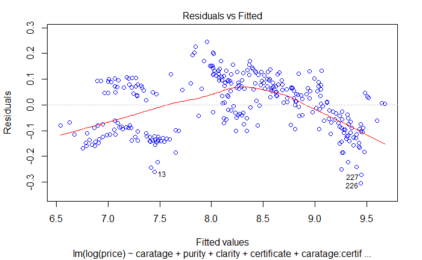

```r
#Let's analyse this model deeper.
# Residuals vs Fitted Plot
residuals_vs_fitted_model.1.5<-plot(model.1.5, which=1, col=c("blue"))
```

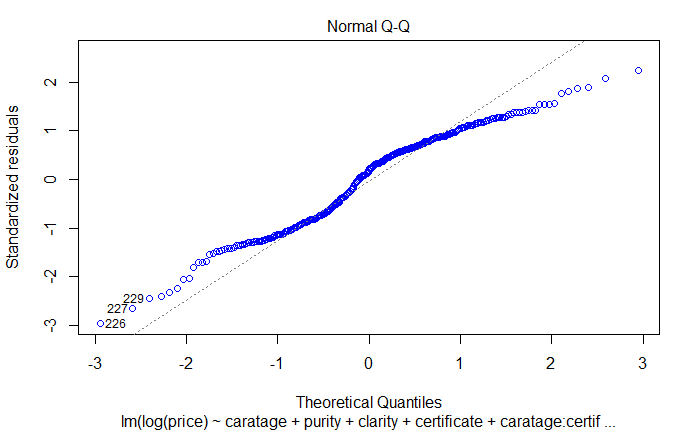

```r
#Normal Q-Q Plot
qq_plot_model.1.5<-plot(model.1.5, which=2, col=c("blue"))
```

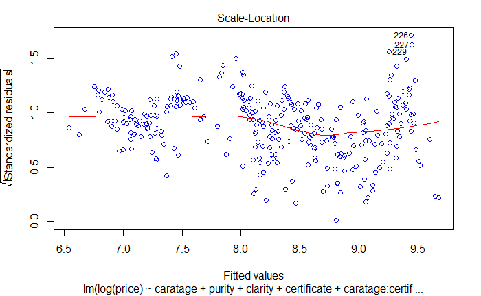

```r
#Scale-Location
residuals_vs_fitted_model.1.5<-plot(model.1.5, which=3, col=c("blue"))
```

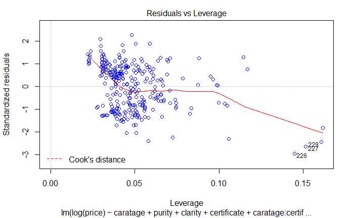

```r
#Residuals vs Leverage
residuals_vs_fitted_model.1.5<-plot(model.1.5, which=5, col=c("blue"))
```

```r
#We use Jarque-Bera to test the residuals
jarque.bera.test(model.1.5$residuals)
```

```
    Jarque Bera Test

data:  model.1.5$residuals
X-squared = 11.785, df = 2, p-value = 0.00276
```

```r
#To test the independance, we do the Durbin-Watson test
dwtest(model.1.5)
```

```
    Durbin-Watson test

data:  model.1.5
DW = 0.43495, p-value < 2.2e-16
alternative hypothesis: true autocorrelation is greater than 0
```

```r
#For constant variance we'd use Breusch-Pagan
bptest(model.1.5)
```

```
    studentized Breusch-Pagan test

data:  model.1.5
BP = 84.825, df = 14, p-value = 3.568e-12
```

```r
# We'll use outlierTest and residualPlot
outlierTest(model.1.5)
```

```
No Studentized residuals with Bonferroni p < 0.05
Largest |rstudent|:
```

|  | rstudent | unadjusted p-value | Bonferroni p |
| --- | --- | --- | --- |
| 226 | -2.995462 | 0.0029752 | 0.91636 |

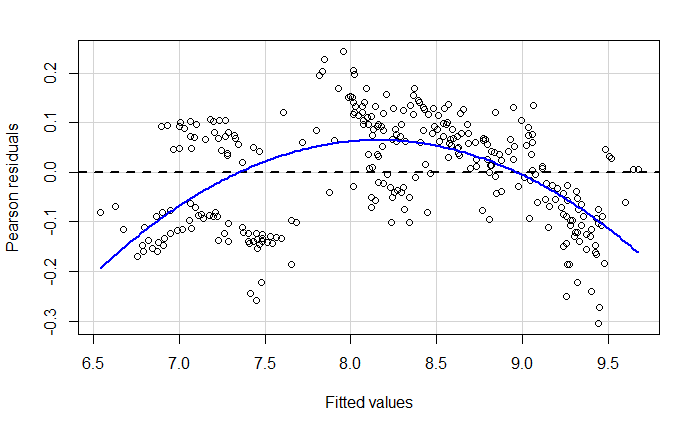

```r
residualPlot(model.1.5)
```

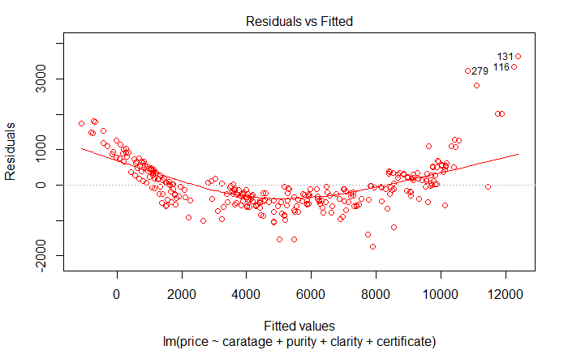

```r
#Are we getting better results than with the previous models? Let's repeat the residual analysis for all and compare the results!
library(ggpubr)
residuals_vs_fitted_model.1.1<-plot(model.1.1, which=1, col=c("red"))
```

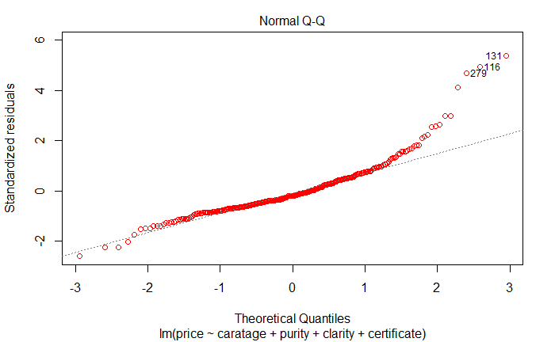

```r
qq_plot_model.1.1<-plot(model.1.1, which=2, col=c("red"))
```

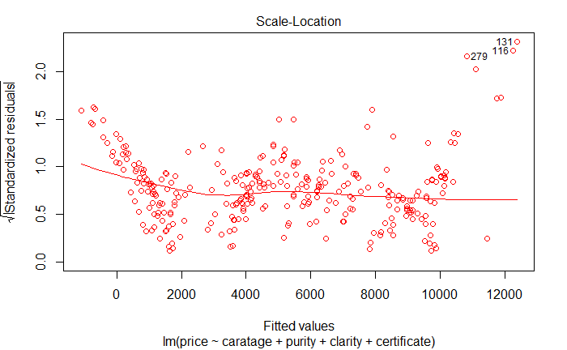

```r
residuals_vs_fitted_model.1.1<-plot(model.1.1, which=3, col=c("red"))
```

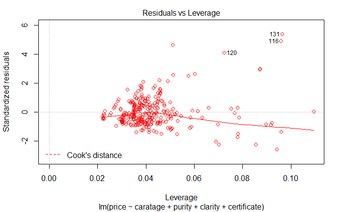

```r
residuals_vs_fitted_model.1.1<-plot(model.1.1, which=5, col=c("red"))
```

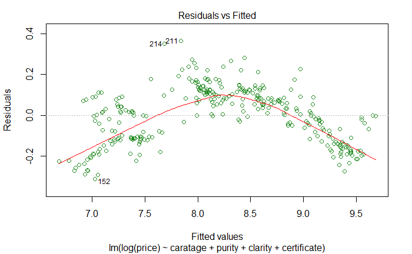

```r
residuals_vs_fitted_model.1.2<-plot(model.1.2, which=1, col=c("forestgreen"))
```

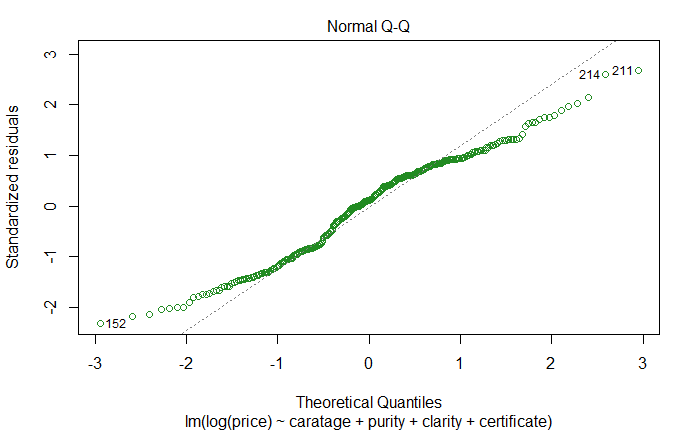

```r
qq_plot_model.1.2<-plot(model.1.2, which=2, col=c("forestgreen"))
```

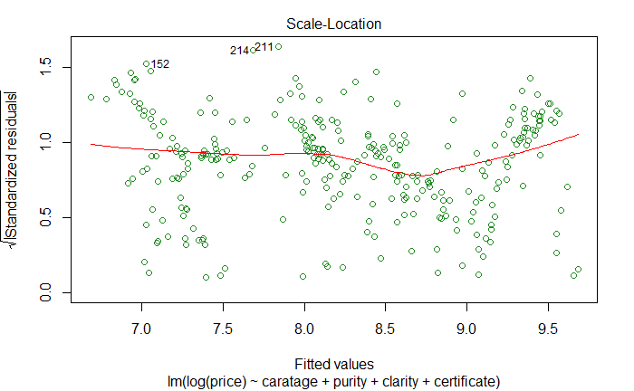

```r
residuals_vs_fitted_model.1.2<-plot(model.1.2, which=3, col=c("forestgreen"))
```

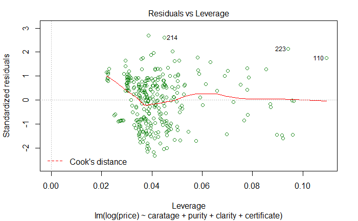

```r
residuals_vs_fitted_model.1.2<-plot(model.1.2, which=5, col=c("forestgreen"))
```

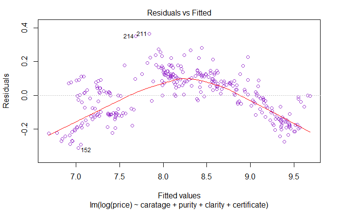

```r
residuals_vs_fitted_model.1.3<-plot(model.1.3, which=1, col=c("darkorchid"))
```

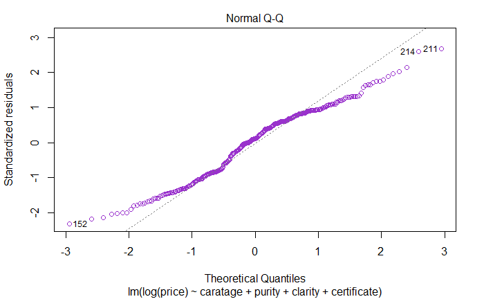

```r
qq_plot_model.1.3<-plot(model.1.3, which=2, col=c("darkorchid"))
```

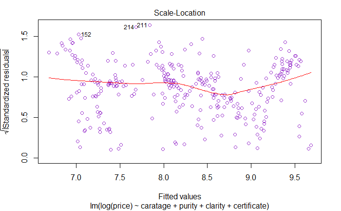

```r
residuals_vs_fitted_model.1.3<-plot(model.1.3, which=3, col=c("darkorchid"))
```

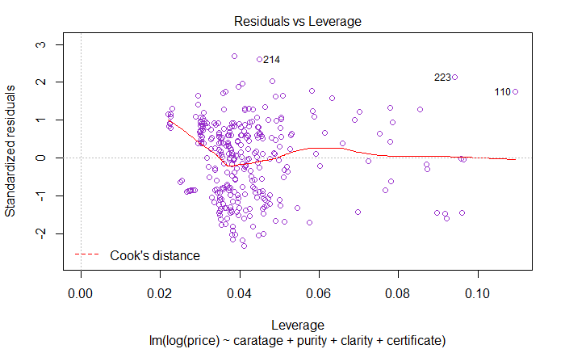

```r
residuals_vs_fitted_model.1.3<-plot(model.1.3, which=5, col=c("darkorchid"))
```

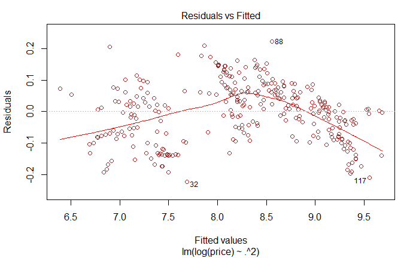

```r
residuals_vs_fitted_model.1.4<-plot(model.1.4, which=1, col=c("brown"))
```

```
not plotting observations with leverage one:
  110
```

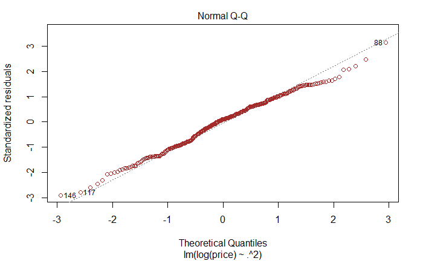

```r
qq_plot_model.1.4<-plot(model.1.4, which=2, col=c("brown"))
```

```
not plotting observations with leverage one:
  110
```

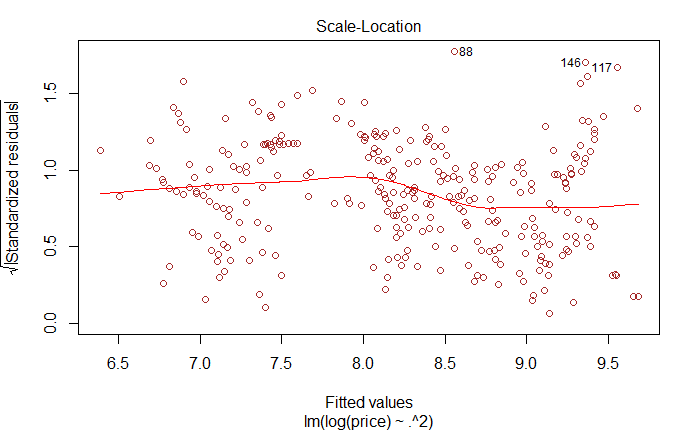

```r
residuals_vs_fitted_model.1.4<-plot(model.1.4, which=3, col=c("brown"))
```

```
not plotting observations with leverage one:
  110
```

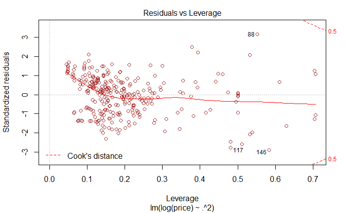

```r
residuals_vs_fitted_model.1.4<-plot(model.1.4, which=5, col=c("brown"))
```

```r
residuals_vs_fitted_all <- ggarrange(
  residuals_vs_fitted_model.1.1,residuals_vs_fitted_model.1.2,residuals_vs_fitted_model.1.3,
  residuals_vs_fitted_model.1.4,residuals_vs_fitted_model.1.5,nrow = 2,ncol = 3)
residuals_vs_fitted_all
```

[output not shown]

```r
qq_plot_all <- ggarrange(
  qq_plot_model.1.1,qq_plot_model.1.2,qq_plot_model.1.3,
  qq_plot_model.1.4,qq_plot_model.1.5,nrow = 2,ncol = 3)
qq_plot_all
```

[output not shown]

### 3. Try two different remedial actions:

### 3a. Create a new categorical variable to segregate the stones according to caratage: let’s say less than 0.5 carats small, 0.5 to less than 1 carat (medium) and 1 carat and over (large). Make small as the reference category. Add this new variable to the existing model as well as an interaction term between this new variable and caratage.

```r
diamonds_new <- mutate(
  diamonds,
  caratage_category = as.factor(
    case_when(
      caratage < 0.5 ~ 's',
      caratage < 1 ~ 'm',
      caratage >= 1 ~ 'l'
      )
    )
  )

diamonds_new$caratage_category <- relevel(diamonds_new$caratage_category, ref = "s")
```

- Is this regression model satisfactory? Are the standard assumptions of linear regression validated? Are the numerical estimates sensible?

The model seems to be better than before, having a Radj value of 0.996

- Interpret the interaction parameter med*carat. What can we infer on the incremental pricing of caratage in the 3 clusters?

- Which is more highly valued: colour or clarity?
- All other things being equal, what is the average price difference between a grade D diamond and another one graded (a) I (b) E?

- All other things being equal, are there price differences amongst the stones appraised by the GIA, IGI and HRD?

There is some difference but it’s really small and also the p-values are higher than 0.05.

```r
#We add Caratage category to the latest model
model.1.5.1 <- lm(formula = log(price) ~ caratage*caratage_category + purity + clarity + certificate + caratage:certificate , data = diamonds_new)
summary(model.1.5.1)
```

```
Call:
lm(formula = log(price) ~ caratage * caratage_category + purity +
    clarity + certificate + caratage:certificate, data = diamonds_new)

Residuals:
      Min        1Q    Median        3Q       Max
-0.155957 -0.038645  0.000459  0.039430  0.140518

Coefficients:
                            Estimate Std. Error t value Pr(>|t|)
(Intercept)                  5.56212    0.05179 107.405  < 2e-16 ***
caratage                     4.15736    0.11097  37.464  < 2e-16 ***
caratage_categoryl           2.26727    0.32215   7.038 1.42e-11 ***
caratage_categorym           0.89856    0.04702  19.112  < 2e-16 ***
purityD                      0.43275    0.01682  25.727  < 2e-16 ***
purityE                      0.34850    0.01251  27.867  < 2e-16 ***
purityF                      0.27391    0.01110  24.681  < 2e-16 ***
purityG                      0.18606    0.01150  16.182  < 2e-16 ***
purityH                      0.10607    0.01147   9.251  < 2e-16 ***
clarityVS1                   0.06631    0.01012   6.556 2.54e-10 ***
clarityVVS2                  0.13544    0.01047  12.936  < 2e-16 ***
clarityVVS1                  0.21551    0.01156  18.635  < 2e-16 ***
clarityIF                    0.31793    0.01390  22.870  < 2e-16 ***
certificateGIA               0.03114    0.03567   0.873    0.384
certificateIGI              -0.04696    0.04266  -1.101    0.272
caratage:caratage_categoryl -3.08089    0.33197  -9.281  < 2e-16 ***
caratage:caratage_categorym -1.64552    0.11085 -14.845  < 2e-16 ***
caratage:certificateGIA     -0.03181    0.04361  -0.729    0.466
caratage:certificateIGI      0.06528    0.05976   1.092    0.276
---
Signif. codes:  0 ‘***’ 0.001 ‘**’ 0.01 ‘*’ 0.05 ‘.’ 0.1 ‘ ’ 1

Residual standard error: 0.05513 on 289 degrees of freedom
Multiple R-squared:  0.9957,    Adjusted R-squared:  0.9954
F-statistic:  3705 on 18 and 289 DF,  p-value: < 2.2e-16
```

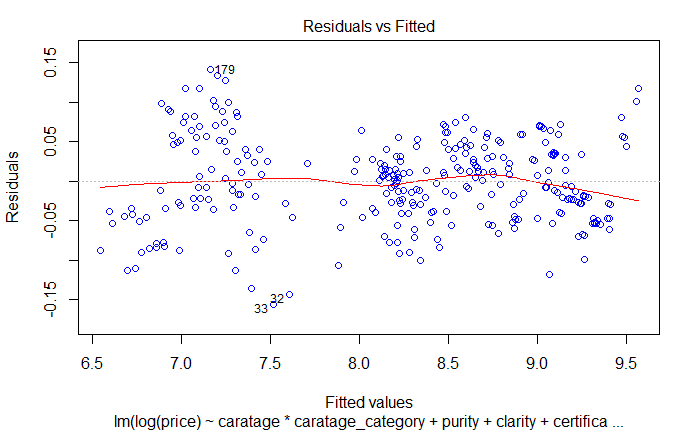

```r
#Let's analyse this model deeper.
# Residuals vs Fitted Plot
residuals_vs_fitted_model.1.5.1<-plot(model.1.5.1, which=1, col=c("blue"))
```

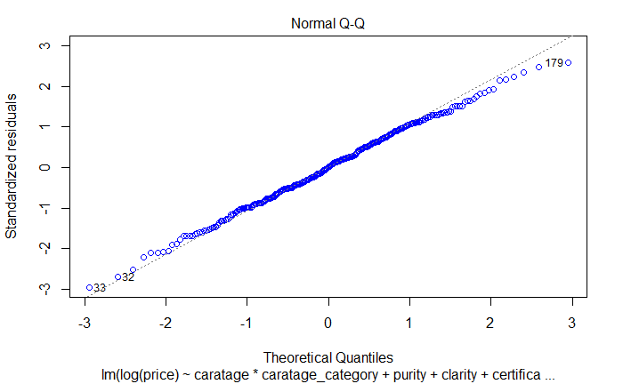

```r
#Normal Q-Q Plot
qq_plot_model.1.5.1<-plot(model.1.5.1, which=2, col=c("blue"))
```

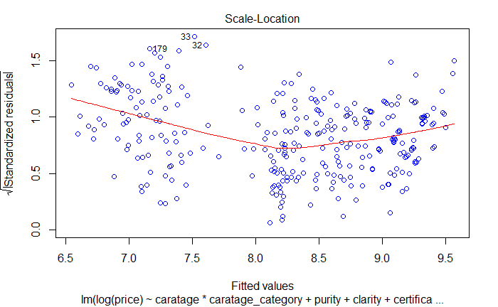

```r
#Scale-Location
residuals_vs_fitted_model.1.5.1<-plot(model.1.5.1, which=3, col=c("blue"))
```

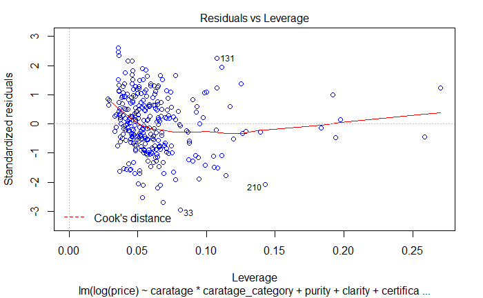

```r
#Residuals vs Leverage
residuals_vs_fitted_model.1.5.1<-plot(model.1.5.1, which=5, col=c("blue"))
```

```r
#We use Jarque-Bera to test the residuals
jarque.bera.test(model.1.5.1$residuals)
```

```
    Jarque Bera Test

data:  model.1.5.1$residuals
X-squared = 0.90364, df = 2, p-value = 0.6365
```

```r
#To test the independance, we do the Durbin-Watson test
dwtest(model.1.5.1)
```

```
    Durbin-Watson test

data:  model.1.5.1
DW = 1.0615, p-value < 2.2e-16
alternative hypothesis: true autocorrelation is greater than 0
```

```r
#For constant variance we'd use Breusch-Pagan
bptest(model.1.5.1)
```

```
    studentized Breusch-Pagan test

data:  model.1.5.1
BP = 63.085, df = 18, p-value = 6.431e-07
```

```r
# We'll use outlierTest and residualPlot
outlierTest(model.1.5.1)
```

```
No Studentized residuals with Bonferroni p < 0.05
Largest |rstudent|:
```

|  | rstudent | unadjusted p-value | Bonferroni p |
| --- | --- | --- | --- |
| 33 | -2.991223 | 0.0030189 | 0.92983 |

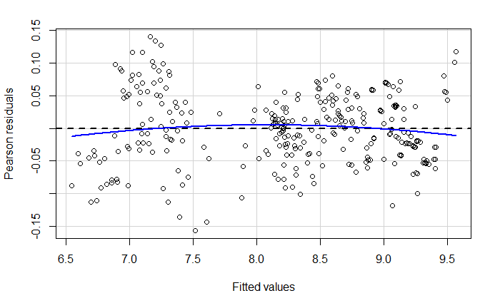

```r
residualPlot(model.1.5.1)
```

```r
# To test if clarity or purity is better than the other
anova(model.1.5.1)
```

```
Analysis of Variance Table

Response: log(price)
                            Df  Sum Sq Mean Sq    F value    Pr(>F)
caratage                     1 190.451 190.451 62655.3695 < 2.2e-16 ***
caratage_category            2   5.838   2.919   960.3107 < 2.2e-16 ***
purity                       5   3.294   0.659   216.7450 < 2.2e-16 ***
clarity                      4   1.706   0.426   140.2999 < 2.2e-16 ***
certificate                  2   0.178   0.089    29.2962 2.601e-12 ***
caratage:caratage_category   2   1.213   0.607   199.5527 < 2.2e-16 ***
caratage:certificate         2   0.015   0.007     2.4321   0.08964 .
Residuals                  289   0.878   0.003
---
Signif. codes:  0 ‘***’ 0.001 ‘**’ 0.01 ‘*’ 0.05 ‘.’ 0.1 ‘ ’ 1
```

### 3b. Include the square of carat as a new explanatory variable. It avoids the subjectivity of clusters definition.

```r
diamonds_c2 <- mutate(
  diamonds,
  caratage2 = caratage^2
  )
model.1.5.2 <- lm(formula = log(price) ~ caratage + caratage2 + purity + clarity + certificate + caratage:purity + caratage:clarity + caratage:certificate , data = diamonds_c2)
summary(model.1.5.2)
```

```
Call:
lm(formula = log(price) ~ caratage + caratage2 + purity + clarity +
    certificate + caratage:purity + caratage:clarity + caratage:certificate,
    data = diamonds_c2)

Residuals:
      Min        1Q    Median        3Q       Max
-0.168287 -0.036215  0.001285  0.035133  0.144420

Coefficients:
                        Estimate Std. Error t value Pr(>|t|)
(Intercept)              5.30379    0.06067  87.422  < 2e-16 ***
caratage                 5.59298    0.12666  44.158  < 2e-16 ***
caratage2               -1.98793    0.07021 -28.313  < 2e-16 ***
purityD                  0.35979    0.04192   8.583 6.24e-16 ***
purityE                  0.38932    0.03224  12.077  < 2e-16 ***
purityF                  0.30177    0.02909  10.373  < 2e-16 ***
purityG                  0.16508    0.02914   5.665 3.61e-08 ***
purityH                  0.03555    0.03106   1.145 0.253270
clarityVS1               0.15506    0.02909   5.331 2.00e-07 ***
clarityVVS2              0.28336    0.03217   8.808  < 2e-16 ***
clarityVVS1              0.36399    0.03602  10.104  < 2e-16 ***
clarityIF                0.45210    0.03528  12.816  < 2e-16 ***
certificateGIA           0.01256    0.03506   0.358 0.720350
certificateIGI          -0.11538    0.04237  -2.723 0.006875 **
caratage:purityD         0.14313    0.05616   2.549 0.011342 *
caratage:purityE        -0.05180    0.04423  -1.171 0.242496
caratage:purityF        -0.03713    0.03928  -0.945 0.345398
caratage:purityG         0.04146    0.04001   1.036 0.301001
caratage:purityH         0.08628    0.04121   2.094 0.037191 *
caratage:clarityVS1     -0.10722    0.03830  -2.799 0.005474 **
caratage:clarityVVS2    -0.19106    0.04177  -4.574 7.17e-06 ***
caratage:clarityVVS1    -0.18901    0.04849  -3.898 0.000121 ***
caratage:clarityIF      -0.16642    0.05376  -3.096 0.002160 **
caratage:certificateGIA -0.02013    0.04320  -0.466 0.641674
caratage:certificateIGI  0.13209    0.05882   2.246 0.025491 *
---
Signif. codes:  0 ‘***’ 0.001 ‘**’ 0.01 ‘*’ 0.05 ‘.’ 0.1 ‘ ’ 1

Residual standard error: 0.05462 on 283 degrees of freedom
Multiple R-squared:  0.9959,    Adjusted R-squared:  0.9955
F-statistic:  2831 on 24 and 283 DF,  p-value: < 2.2e-16
```

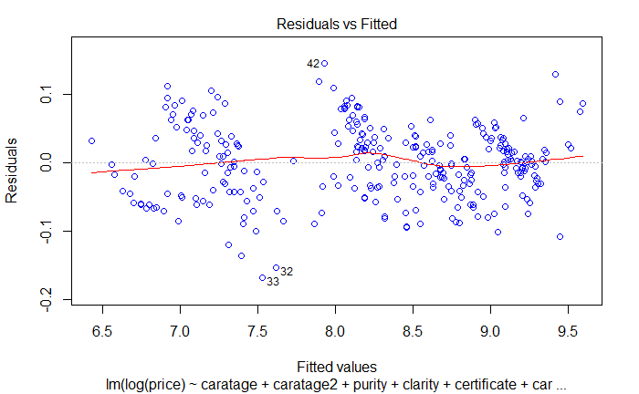

```r
#Let's analyse this model deeper.
# Residuals vs Fitted Plot
residuals_vs_fitted_model.1.5.2<-plot(model.1.5.2, which=1, col=c("blue"))
```

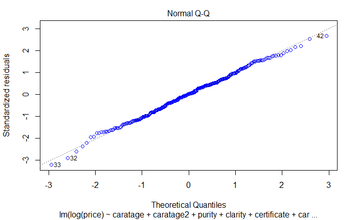

```r
#Normal Q-Q Plot
qq_plot_model.1.5.2<-plot(model.1.5.2, which=2, col=c("blue"))
```

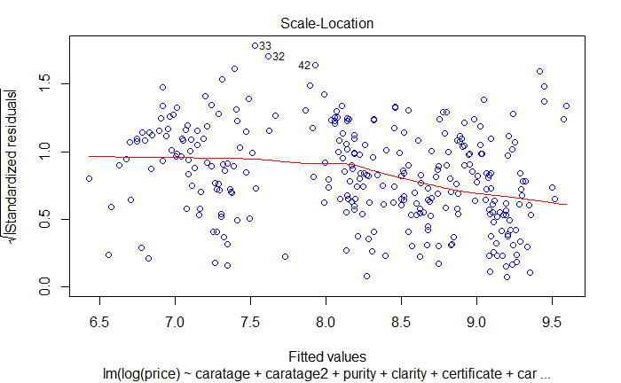

```r
#Scale-Location
residuals_vs_fitted_model.1.5.2<-plot(model.1.5.2, which=3, col=c("blue"))
```

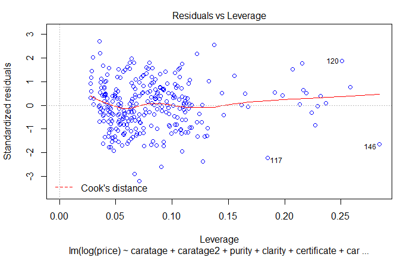

```r
#Residuals vs Leverage
residuals_vs_fitted_model.1.5.2<-plot(model.1.5.2, which=5, col=c("blue"))
```

```r
#We use Jarque-Bera to test the residuals
jarque.bera.test(model.1.5.2$residuals)
```

```
    Jarque Bera Test

data:  model.1.5.2$residuals
X-squared = 0.56178, df = 2, p-value = 0.7551
```

```r
#To test the independance, we do the Durbin-Watson test
dwtest(model.1.5.2)
```

```
    Durbin-Watson test

data:  model.1.5.2
DW = 0.98541, p-value < 2.2e-16
alternative hypothesis: true autocorrelation is greater than 0
```

```r
#For constant variance we'd use Breusch-Pagan
bptest(model.1.5.2)
```

```
    studentized Breusch-Pagan test

data:  model.1.5.2
BP = 40.703, df = 24, p-value = 0.01795
```

```r
# We'll use outlierTest and residualPlot
outlierTest(model.1.5.2)
```

```
No Studentized residuals with Bonferroni p < 0.05
Largest |rstudent|:
```

|  | rstudent | unadjusted p-value | Bonferroni p |
| --- | --- | --- | --- |
| 33 | -3.2501 | 0.0012935 | 0.39839 |

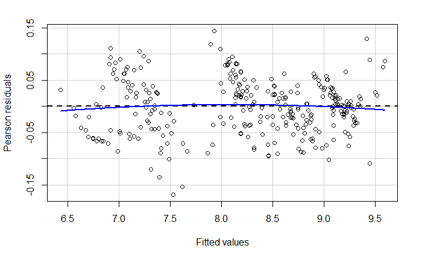

```r
residualPlot(model.1.5.2)
```